# DGG Grid System

# DGG Grid System

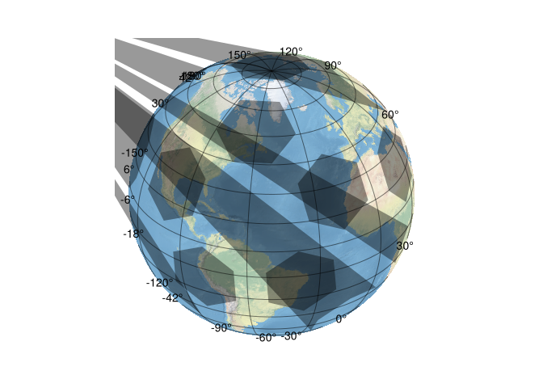

```julia
using GlobalGrids, GeoMakie, CairoMakie

grid = ISEA3H()

cells_r0 = [ISEA3HCell(i, Int[]) for i in 0:19]

fig = Figure()
ax = GeoAxis(fig[1,1], dest = "+proj=ortho +lon_0=-50 +lat_0=30")
poly!(ax, cells_r0, color=(:black, .4))

ep = surface!(ax,
    -180..180, -90..90,
    zeros(axes(rotr90(GeoMakie.earth())));
    shading = NoShading, color = rotr90(GeoMakie.earth())
)
translate!(ep, 0, 0, -1)

fig
```

The DGG (Discrete Global Grid) module provides parametric grid types inspired by DGGRID. Grid configuration is encoded in type parameters, enabling zero-cost dispatch across different projections, apertures, and topologies.

## Grid Configuration

A DGG grid is parameterized by three values:

| Parameter | Options | Description |
| --- | --- | --- |
| **Projection** | `:isea`, `:fuller` | Map projection (currently uses Lambert azimuthal equal-area) |
| **Aperture** | `3`, `4`, `7`, `43` | Number of child cells per parent (currently `3` is implemented) |
| **Topology** | `:hex`, `:tri`, `:diamond` | Cell shape (currently `:hex` is implemented) |

This gives **12 preset grid types**, each with a corresponding cell type:

| Grid | Cell | Description |
| --- | --- | --- |
| `ISEA3H` | `ISEA3HCell` | ISEA aperture-3 hexagonal |
| `ISEA4H` | `ISEA4HCell` | ISEA aperture-4 hexagonal |
| `ISEA7H` | `ISEA7HCell` | ISEA aperture-7 hexagonal |
| `ISEA43H` | `ISEA43HCell` | ISEA mixed 4-3 hexagonal |
| `ISEA4T` | `ISEA4TCell` | ISEA aperture-4 triangular |
| `ISEA4D` | `ISEA4DCell` | ISEA aperture-4 diamond |
| `FULLER3H` | `FULLER3HCell` | Fuller aperture-3 hexagonal |
| `FULLER4H` | `FULLER4HCell` | Fuller aperture-4 hexagonal |
| `FULLER7H` | `FULLER7HCell` | Fuller aperture-7 hexagonal |
| `FULLER43H` | `FULLER43HCell` | Fuller mixed 4-3 hexagonal |
| `FULLER4T` | `FULLER4TCell` | Fuller aperture-4 triangular |
| `FULLER4D` | `FULLER4DCell` | Fuller aperture-4 diamond |

**Note**

Currently only **aperture-3 hexagonal** grids (`ISEA3H`, `FULLER3H`) are fully implemented. Other apertures and topologies are defined in the type system but not yet functional.

## Cell Index Layout

Each cell wraps a single `UInt64` encoding the base face (0-19) and hierarchical digits:

| Aperture | Bits/digit | Max digits | Max resolution |
| --- | --- | --- | --- |
| 3, 4 | 2 | 29 | 29 |
| 7, 43 | 3 | 19 | 19 |

**Cell count** at resolution $r$ with aperture $A$: $\;20 \cdot A^r$

At resolution 0, there are 20 base cells corresponding to the 20 faces of the icosahedron. All cells are hexagons (no pentagons in the face-based addressing scheme).

## Creating a DGGCell

### From Coordinates and Resolution

```julia
coord = LonLat(-75.0, 54.0)
cell = ISEA3HCell(coord, 5)
```

```
  ⬡ DGGCell 5 0-00021
```

### From Base Face and Digits

```julia
# Base face 0, digits [1, 2, 0]
cell = ISEA3HCell(0, [1, 2, 0])
```

```
  ⬡ DGGCell 3 0-120
```

### From Hex String

```julia
cell = ISEA3HCell(coord, 5)
str = encode(cell)
@info str
ISEA3HCell(str)
```

```
[ Info: 9ffffffffffff
```

```
  ⬡ DGGCell 5 0-00021
```

### Using the Convenience Wrapper

```julia
# dggcells defaults to ISEA3H
dggcells(LonLat(0.0, 0.0), 5)
```

```
1-element Vector{ISEA3HCell}:
   ⬡ DGGCell 5 2-02111
```

## Inspecting Cells

```julia
cell = ISEA3HCell(LonLat(-75.0, 54.0), 5)

@show resolution(cell)
@show is_pentagon(cell)
@show GlobalGrids.digits(cell)
@show base_cell(cell)
@show decode(cell)
@show encode(cell)
nothing
```

```
resolution(cell) = 5
is_pentagon(cell) = false
GlobalGrids.digits(cell) = [0, 0, 0, 2, 1]
base_cell(cell) = 0
decode(cell) = "0-00021"
encode(cell) = "9ffffffffffff"
```

## GeoInterface

```julia
import GeoInterface as GI

cell = ISEA3HCell(LonLat(-75.0, 54.0), 5)

@show GI.centroid(cell)
@show GI.coordinates(cell)
@show GI.area(cell)  # meters²
nothing
```

```
GI.centroid(cell) = LonLat{Float64} (-74.80647024233285, 53.05197910471103)
GI.coordinates(cell) = GlobalGrids.LonLat{Float64}[LonLat{Float64} (-76.91521522049418, 51.774045987604815), LonLat{Float64} (-74.11520152663938, 51.29823891022437), LonLat{Float64} (-71.9503424158508, 52.5233039946571), LonLat{Float64} (-72.57483691601311, 54.28987114368925), LonLat{Float64} (-75.5…
GI.area(cell) = 1.049517740173022e11
```

## Grid Hierarchy

- `parent`, `siblings`, and `children`

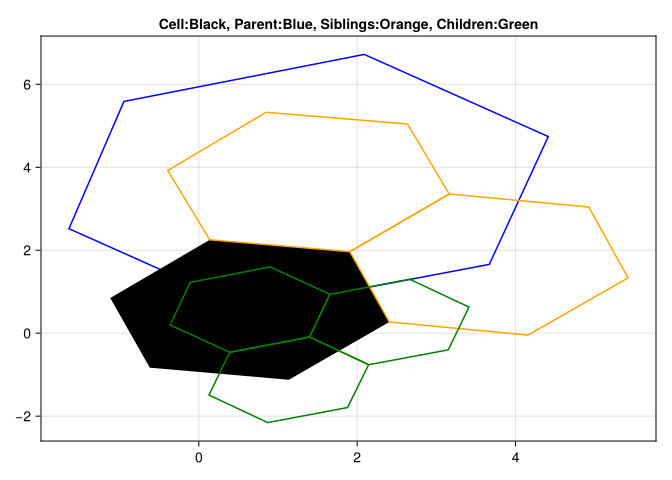

```julia
cell = ISEA3HCell(LonLat(0.0, 0.0), 5)

fig = Figure()
ax = Axis(fig[1,1], title="Cell:Black, Parent:Blue, Siblings:Orange, Children:Green")
lines!(ax, GlobalGrids.parent(cell), color = :blue)
poly!(ax, cell, color = :black)
lines!(ax, siblings(cell), color = :orange)
lines!(ax, children(cell), color = :green)
fig
```

## Quantizing Geometries

### Point

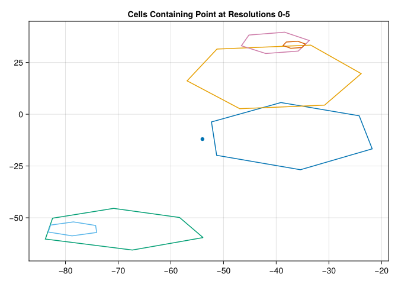

```julia
ll = LonLat(-54.0, -12.0)

fig = Figure()
ax = Axis(fig[1,1], title="Cells Containing Point at Resolutions 0-5")
for res in 0:5
    lines!(ax, dggcells(ll, res))
end
scatter!(ax, ll)

fig
```

### MultiPoint

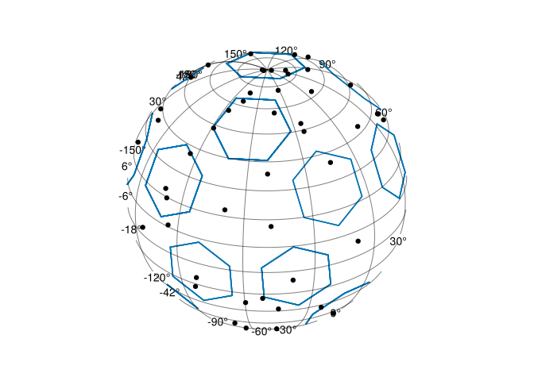

```julia
coords = [LonLat(360rand() - 180, 180rand() - 90) for _ in 1:100]

x = ISEA3HCell.(coords, 0)

f, a, p = lines(x, axis=(;type=GeoAxis, dest = "+proj=ortho +lon_0=-50 +lat_0=30"))
scatter!(a, coords, color=:black)
f
```

### Line

- Containment options for lines: `:center` and `:shortest_path`.

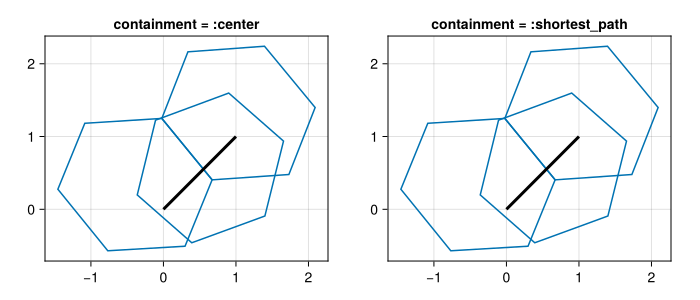

```julia
line = GI.Line([LonLat(0, 0), LonLat(1,1)])

fig = Figure(size=(700, 300))

for (i, containment) in enumerate((:center, :shortest_path))
    ax = Axis(fig[1, i], aspect=DataAspect(), title="containment = :$containment")
    x = dggcells(line, 6; containment)
    lines!(ax, x)
    lines!(ax, GI.coordinates(line), linewidth=3, color = :black)
end

fig
```

### Polygon

- Containment modes for polygons:
  - `:center`: Include cell if its center is inside the polygon.
  - `:overlap`: Include cell if any part intersects the polygon.

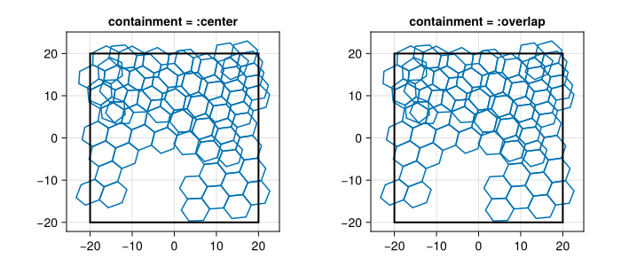

```julia
boundary = [(-20.0, -20.0), (-20.0, 20.0), (20.0, 20.0), (20.0, -20.0), (-20.0, -20.0)]
poly = GI.Polygon([boundary])

fig = Figure(size=(700, 300))

for (i, containment) in enumerate((:center, :overlap))
    ax = Axis(fig[1, i], aspect=DataAspect(), title="containment = :$containment")
    x = dggcells(poly, 4; containment)
    lines!(ax, x)
    lines!(ax, GI.LineString(boundary), linewidth=2, color=:black)
end

fig
```

## Comparison with IGEO7

Both DGG (aperture-3) and IGEO7 (aperture-7) use Lambert azimuthal equal-area projection on the icosahedron. Key differences:

|  | ISEA3H | IGEO7 |
| --- | --- | --- |
| Base cells | 20 faces | 12 vertices |
| Aperture | 3 | 7 |
| Children per cell | 3 | 7 (hex) / 6 (pentagon) |
| Pentagons | None | 12 at each resolution |
| Digits | 0-2 | 0-6 |
| Rotation per level | 30° | 19.1° |
| Max resolution | 29 | 20 |
| Cells at res 5 | 4,860 | 168,072 |